# CRAN growth

In the past 3 months, 504 new packages were added to the CRAN package repository. 104 packages were unarchived, 173 were archived and 1 had to be removed. The following shows the growth of the number of active packages in the CRAN package repository:

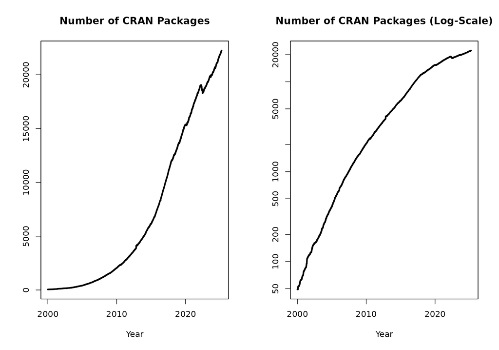

On 2024-12-31, the number of active packages was around 21860.

# CRAN package submissions

From October 2024 to December 2024 CRAN received 6179 package submissions. For these, 9795 actions took place of which 7408 (76%) were auto processed actions and 2387 (24%) manual actions.

Minus some special cases, a summary of the auto-processed and manually triggered actions follows:

|  | archive | inspect | newbies | pending | pretest | publish | recheck | waiting |
| --- | --- | --- | --- | --- | --- | --- | --- | --- |
| auto | 2129 | 490 | 1403 | 96 | 0 | 1991 | 668 | 290 |
| manual | 986 | 0 | 8 | 3 | 27 | 1072 | 226 | 58 |

These include the final decisions for the submissions which were

|  | archive | publish |
| --- | --- | --- |
| auto | 2056 (33.7%) | 1805 (29.6%) |
| manual | 982 (16.1%) | 1254 (20.6%) |

where we only count those as *auto* processed whose publication or rejection happened automatically in all steps.

# CRAN mirror security

Currently, there are 94 official CRAN mirrors, 73 of which provide both secure downloads via ‘`https`’ *and* use secure mirroring from the CRAN master (via rsync through ssh tunnels). Since the R 3.4.0 release, `chooseCRANmirror()` offers these mirrors in preference to the others which are not fully secured (yet).

# CRAN Task View Initiative

There is one new task view:

- Paleontology: Maintained by William Gearty, Lewis A. Jones, Erin Dillon, Pedro Godoy, Harriet Drage, Christopher Dean, Bruna Farina.

Currently there are 48 task views (see https://CRAN.R-project.org/web/views/), with median and mean numbers of CRAN packages covered 110 and 121, respectively. Overall, these task views cover 4885 CRAN packages, which is about 22% of all active CRAN packages.